# Final Markdown

Elizabeth Elsen

2024-12-11

```r
knitr::opts_chunk$set(echo = TRUE)

library(readr)
library(dplyr)
library(lubridate) # date and time
library(tidyverse)
library(ggplot2)
library(corrplot) # correlation package
library(clustMixType) # k proto clustering
library(gridExtra) # for cluster histogram arrangement
library(rcompanion) # CramerV test

set.seed(123)  # For reproducibility


load("cluster_df_clean_region.RData") # has all clusters loaded already
load("cor_matrix.RData")
load("universal_top_spotify_songs.RData")
load("cluster_df_clean.RData")
```

### Originally importing the data.

```r
universal_top_spotify_songs <- read_csv("universal_top_spotify_songs.csv",
                                        col_types = cols(snapshot_date = col_datetime(format = "%Y-%m-%d"),
                                                         album_release_date = col_datetime(format = "%Y-%m-%d"),
                                                         key = col_factor(levels = c("0",
                                                                                     "1", "2", "3", "4", "5", "6",
                                                                                     "7", "8", "9", "10", "11")),
                                                         mode = col_factor(levels = c("0",
                                                                                      "1")), time_signature = col_factor(levels = c("0",
                                                                                                                                    "1", "2", "3", "4", "5"))))


# adding columns
universal_top_spotify_songs <- universal_top_spotify_songs %>%
  mutate(key_mode = paste(key, "in", mode),
         age = difftime(universal_top_spotify_songs$snapshot_date,
                        universal_top_spotify_songs$album_release_date,
                        units = "days")
         )


# getting only the date with peak popularity
universal_top_spotify_songs <- universal_top_spotify_songs %>%
  group_by(spotify_id) %>%
  filter(popularity == max(popularity)) %>%
  ungroup()


overall_df <- universal_top_spotify_songs %>%
  filter(is.na(country))


# creating country lists

latin_american <- c("MX", "SV", "GT", "HN", "NI", "CR", "PA", "DO", "VE", "CO", "EC", "PE", "BO", "CL", "AR", "PY", "UY")

portuguese_speaking <- c("BR", "PT")

east_asian <- c("JP", "KR", "TW", "VN", "HK")

southeast_asian <- c("TH", "PH", "MY", "ID", "SG")

south_central_asian <- c("IN", "PK", "KZ")

middle_eastern <- c("SA", "AE", "IL", "EG")

nordic_scandinavian <- c("SE", "NO", "DK", "FI", "IS")

western_european <- c("FR", "ES", "IT", "DE", "NL", "BE", "LU", "CH", "AT")

eastern_european <- c("UA", "RO", "PL", "HU", "CZ", "SK", "EE", "LV", "LT", "BG", "BY")

african <- c("ZA", "NG", "MA")

anglo_western <- c("US", "CA", "GB", "IE", "AU", "NZ")



universal_top_spotify_songs$region <- case_when(
  universal_top_spotify_songs$country %in% latin_american ~ "Latin American",
  universal_top_spotify_songs$country %in% portuguese_speaking ~ "Portuguese-Speaking",
  universal_top_spotify_songs$country %in% east_asian ~ "East Asian",
  universal_top_spotify_songs$country %in% southeast_asian ~ "Southeast Asian",
  universal_top_spotify_songs$country %in% south_central_asian ~ "South-Central Asian",
  universal_top_spotify_songs$country %in% middle_eastern ~ "Middle Eastern",
  universal_top_spotify_songs$country %in% nordic_scandinavian ~ "Nordic/Scandinavian",
  universal_top_spotify_songs$country %in% western_european ~ "Western European",
  universal_top_spotify_songs$country %in% eastern_european ~ "Eastern European",
  universal_top_spotify_songs$country %in% african ~ "African",
  universal_top_spotify_songs$country %in% anglo_western ~ "Anglo-Western",
  TRUE ~ "Overall" # Fallback category for any unmatched countries
)



# filtering data frames for each group

latin_american_df <- universal_top_spotify_songs %>%
  filter(country %in% latin_american)

portuguese_speaking_df <- universal_top_spotify_songs %>%
  filter(country %in% portuguese_speaking)

east_asian_df <- universal_top_spotify_songs %>%
  filter(country %in% east_asian)

southeast_asian_df <- universal_top_spotify_songs %>%
  filter(country %in% southeast_asian)

south_central_asian_df <- universal_top_spotify_songs %>%
  filter(country %in% south_central_asian)

middle_eastern_df <- universal_top_spotify_songs %>%
  filter(country %in% middle_eastern)

nordic_scandinavian_df <- universal_top_spotify_songs %>%
  filter(country %in% nordic_scandinavian)

western_european_df <- universal_top_spotify_songs %>%
  filter(country %in% western_european)

eastern_european_df <- universal_top_spotify_songs %>%
  filter(country %in% eastern_european)

african_df <- universal_top_spotify_songs %>%
  filter(country %in% african)

anglo_western_df <- universal_top_spotify_songs %>%
  filter(country %in% anglo_western)



# summary creation by mode or whichever variable

calculate_averages_by_diff <- function(data, group_var = "mode") {
  data %>%
    group_by(across(all_of(group_var))) %>%
    summarise(
      number_in_section = n_distinct(spotify_id),
      avg_age = mean(age, na.rm = TRUE),
      avg_danceability = mean(danceability, na.rm = TRUE),
      avg_explicit = mean(as.numeric(is_explicit), na.rm = TRUE),
      avg_duration = mean(duration_ms, na.rm = TRUE),
      avg_energy = mean(energy, na.rm = TRUE),
      avg_loudness = mean(loudness, na.rm = TRUE),
      avg_speechiness = mean(speechiness, na.rm = TRUE),
      avg_acousticness = mean(acousticness, na.rm = TRUE),
      avg_instrumentalness = mean(instrumentalness, na.rm = TRUE),
      avg_liveness = mean(liveness, na.rm = TRUE),
      avg_valence = mean(valence, na.rm = TRUE),
      avg_tempo = mean(tempo, na.rm = TRUE),

      median_age = median(age, na.rm = TRUE),
      median_danceability = median(danceability, na.rm = TRUE),
      median_explicit = median(as.numeric(is_explicit), na.rm = TRUE),
      median_duration = median(duration_ms, na.rm = TRUE),
      median_energy = median(energy, na.rm = TRUE),
      median_loudness = median(loudness, na.rm = TRUE),
      median_speechiness = median(speechiness, na.rm = TRUE),
      median_acousticness = median(acousticness, na.rm = TRUE),
      median_instrumentalness = median(instrumentalness, na.rm = TRUE),
      median_liveness = median(liveness, na.rm = TRUE),
      median_valence = median(valence, na.rm = TRUE),
      median_tempo = median(tempo, na.rm = TRUE)
    )
}



# overall averages

calculate_averages <- function(data) {
  data %>%
    summarise(
      number_in_section = n_distinct(spotify_id),
      avg_age = mean(age, na.rm = TRUE),
      avg_danceability = mean(danceability, na.rm = TRUE),
      avg_explicit = mean(as.numeric(is_explicit), na.rm = TRUE),
      avg_duration = mean(duration_ms, na.rm = TRUE),
      avg_energy = mean(energy, na.rm = TRUE),
      avg_loudness = mean(loudness, na.rm = TRUE),
      avg_speechiness = mean(speechiness, na.rm = TRUE),
      avg_acousticness = mean(acousticness, na.rm = TRUE),
      avg_instrumentalness = mean(instrumentalness, na.rm = TRUE),
      avg_liveness = mean(liveness, na.rm = TRUE),
      avg_valence = mean(valence, na.rm = TRUE),
      avg_tempo = mean(tempo, na.rm = TRUE),

      median_age = median(age, na.rm = TRUE),
      median_danceability = median(danceability, na.rm = TRUE),
      median_explicit = median(as.numeric(is_explicit), na.rm = TRUE),
      median_duration = median(duration_ms, na.rm = TRUE),
      median_energy = median(energy, na.rm = TRUE),
      median_loudness = median(loudness, na.rm = TRUE),
      median_speechiness = median(speechiness, na.rm = TRUE),
      median_acousticness = median(acousticness, na.rm = TRUE),
      median_instrumentalness = median(instrumentalness, na.rm = TRUE),
      median_liveness = median(liveness, na.rm = TRUE),
      median_valence = median(valence, na.rm = TRUE),
      median_tempo = median(tempo, na.rm = TRUE)
    )
}

# using the function

overall_averages <- calculate_averages(overall_df)

latin_american_averages <- calculate_averages(latin_american_df)

portuguese_speaking_averages <- calculate_averages(portuguese_speaking_df)

east_asian_averages <- calculate_averages(east_asian_df)

southeast_asian_averages <- calculate_averages(southeast_asian_df)

south_central_asian_averages <- calculate_averages(south_central_asian_df)

middle_eastern_averages <- calculate_averages(middle_eastern_df)

nordic_scandinavian_averages <- calculate_averages(nordic_scandinavian_df)

western_european_averages <- calculate_averages(western_european_df)

eastern_european_averages <- calculate_averages(eastern_european_df)

african_averages <- calculate_averages(african_df)

anglo_western_averages <- calculate_averages(anglo_western_df)

overall_averages$place <- "Overall"

latin_american_averages$place <- "Latin American"

portuguese_speaking_averages$place <- "Portuguese Speaking"

east_asian_averages$place <- "East Asian"

southeast_asian_averages$place <- "Southeast Asian"

south_central_asian_averages$place <- "South Centeral Asian"

middle_eastern_averages$place <- "Middle Eastern"

nordic_scandinavian_averages$place <- "Nordic Scandinavian"

western_european_averages$place <- "Western European"

eastern_european_averages$place <- "Eastern European"

african_averages$place <- "African"

anglo_western_averages$place <- "Anglo Western"


all_averages <- rbind(overall_averages,latin_american_averages,portuguese_speaking_averages,
                      east_asian_averages,southeast_asian_averages, south_central_asian_averages,
                      middle_eastern_averages,nordic_scandinavian_averages,western_european_averages,
                      eastern_european_averages,african_averages,anglo_western_averages)



rm(overall_averages,latin_american_averages,portuguese_speaking_averages,
   east_asian_averages,southeast_asian_averages, south_central_asian_averages,
   middle_eastern_averages,nordic_scandinavian_averages,western_european_averages,
   eastern_european_averages,african_averages,anglo_western_averages)



#seasons
#####

# making seperate dfs by season of year
winter <- c("December","January","Febuary")
spring <- c("March","April","May")
summer <- c("June","July","August")
fall <- c("September","October","November")


# should divine it up by years:

df2023 <- universal_top_spotify_songs %>%
  filter(year(snapshot_date) == 2023)

df2024 <- universal_top_spotify_songs %>%
  filter(year(snapshot_date) == 2024)


winter_df_2023 <- df2023 %>%
  filter(months(snapshot_date) %in% winter)

# anything before fall 2023 is not included

fall_df_2023 <- df2023 %>%
  filter(months(snapshot_date) %in% fall)

winter_df_2024 <- df2024 %>%
  filter(months(snapshot_date) %in% winter)


spring_df_2024 <- df2024 %>%
  filter(months(snapshot_date) %in% spring)


summer_df_2024 <- df2024 %>%
  filter(months(snapshot_date) %in% summer)


fall_df_2024 <- df2024 %>%
  filter(months(snapshot_date) %in% fall)



winter_averages_2023 <- calculate_averages(winter_df_2023)

# spring_averages_2023 <- calculate_averages(spring_df_2023)
#
# summer_averages_2023 <- calculate_averages(summer_df_2023)

fall_averages_2023 <- calculate_averages(fall_df_2023)


winter_averages_2024 <- calculate_averages(winter_df_2024)

spring_averages_2024 <- calculate_averages(spring_df_2024)

summer_averages_2024 <- calculate_averages(summer_df_2024)

fall_averages_2024 <- calculate_averages(fall_df_2024)



fall_averages_2024$time <- "fall 24"
winter_averages_2024$time <- "winter 24"
summer_averages_2024$time <- "summer 24"
spring_averages_2024$time <- "spring 24"

fall_averages_2023$time <- "fall 23"
winter_averages_2023$time <- "winter 23"
# summer_averages_2023$time <- "summer 23"
# spring_averages_2023$time <- "spring 23"





all_averages_seasons <- rbind(fall_averages_2024,summer_averages_2024,
                              spring_averages_2024,fall_averages_2023,
                              winter_averages_2023, winter_averages_2024)
```

## EDA Shiny App

### Explores Distribution of Categorical and Numerical Variables over Mode and Region

### Explores Averages around the world and over time.

```r
knitr::include_app("https://elizabethelsen80.shinyapps.io/Final_EDA/", height = "700px")
```

[interactive chart not shown]

### Note the numerical distributions are not normal.

```r
cluster_df_clean_cov <- cluster_df_clean%>%
  na.omit() %>%
  select( -is_explicit, -key, -mode, -time_signature, -spotify_id, -region)


cov_matrix <- cov(cluster_df_clean_cov)

# Convert the covariance matrix to a correlation matrix
cor_matrix <- cov2cor(cov_matrix)
```

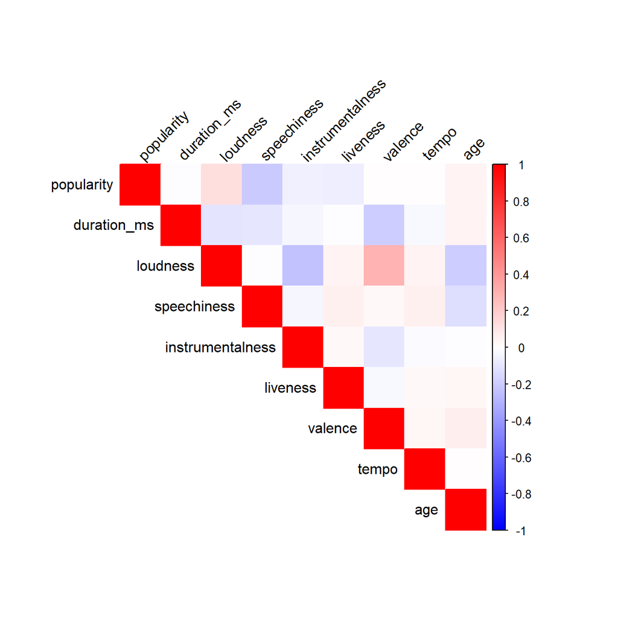

```r
# Plot the correlation matrix using corrplot
corrplot(cor_matrix, method = "color", type = "upper",
         col = colorRampPalette(c("blue", "white", "red"))(200),
         tl.col = "black", tl.srt = 45)
```

```r
universal_top_spotify_songs_section <- universal_top_spotify_songs[sample(nrow
                                                                          (universal_top_spotify_songs)
                                                                          , size = 1000),]

contingency_table <- table(universal_top_spotify_songs_section$mode, universal_top_spotify_songs_section$key)
chisq.test(contingency_table)
```

```
##
##  Pearson's Chi-squared test
##
## data:  contingency_table
## X-squared = 103.04, df = 11, p-value < 2.2e-16
```

```r
cramerV <- cramerV(contingency_table, bias.correct = TRUE)
print(cramerV)
```

```
## Cramer V
##   0.3035
```

```r
contingency_table <- table(universal_top_spotify_songs_section$mode, universal_top_spotify_songs_section$is_explicit)
chisq.test(contingency_table)
```

```
##
##  Pearson's Chi-squared test with Yates' continuity correction
##
## data:  contingency_table
## X-squared = 6.3312, df = 1, p-value = 0.01186
```

```r
cramerV <- cramerV(contingency_table, bias.correct = TRUE)
print(cramerV)
```

```
## Cramer V
##  0.07532
```

```r
contingency_table <- table(universal_top_spotify_songs_section$is_explicit, universal_top_spotify_songs_section$key)
chisq.test(contingency_table)
```

```
##
##  Pearson's Chi-squared test
##
## data:  contingency_table
## X-squared = 17.186, df = 11, p-value = 0.1025
```

```r
cramerV <- cramerV(contingency_table, bias.correct = TRUE)
print(cramerV)
```

```
## Cramer V
##  0.07862
```

```r
contingency_table <- table(universal_top_spotify_songs_section$mode,
                           as.factor(universal_top_spotify_songs_section$region))
chisq.test(contingency_table)
```

```
##
##  Pearson's Chi-squared test
##
## data:  contingency_table
## X-squared = 56.431, df = 11, p-value = 4.235e-08
```

```r
cramerV <- cramerV(contingency_table, bias.correct = TRUE)
print(cramerV)
```

```
## Cramer V
##   0.2132
```

```r
contingency_table <- table(universal_top_spotify_songs_section$key,
                           as.factor(universal_top_spotify_songs_section$region))
chisq.test(contingency_table)
```

```
##
##  Pearson's Chi-squared test
##
## data:  contingency_table
## X-squared = 151.82, df = 121, p-value = 0.0303
```

```r
cramerV <- cramerV(contingency_table, bias.correct = TRUE)
print(cramerV)
```

```
## Cramer V
##  0.05312
```

```r
contingency_table <- table(universal_top_spotify_songs_section$is_explicit,
                           as.factor(universal_top_spotify_songs_section$region))
chisq.test(contingency_table)
```

```
##
##  Pearson's Chi-squared test
##
## data:  contingency_table
## X-squared = 71.339, df = 11, p-value = 6.794e-11
```

```r
cramerV <- cramerV(contingency_table, bias.correct = TRUE)
print(cramerV)
```

```
## Cramer V
##   0.2457
```

### There were no significant correlations with the numerical variables.

### Unlike with the numerical calculations which benefit from a higher sample size, I took a sample for the chi^2 test because it is sensitive to large data sets.

#### The Cramer V test says if the results of the Chi^2 test were effected by sample size. We want values below 0.3 for moderately low effect.

#### I belive that the sample size affected the extremely low p value for the first test.

```r
cluster_df_region <- universal_top_spotify_songs %>%
  subset(select = c(-name, -artists, -daily_rank, -daily_movement, -weekly_movement,
                    -snapshot_date, -album_name, -album_release_date, -country,
                    -key_mode
                    ))


cluster_df_clean_region <- na.omit(cluster_df_region)# Remove rows with NA

cluster_df_clean <- cluster_df_clean_region %>%
  select(-region, -mode)



# Standardize numeric variables (if needed)
cluster_df_clean_scaled <- cluster_df_clean_cov %>%
  mutate(across(where(is.numeric), scale))
```

```r
set.seed(123)  # For reproducibility
# Function to compute within-cluster sum of squares (wss) for k-prototypes
elbow_method <- function(data, max_k = 10) {
  wss <- numeric(max_k)
  for (k in 1:max_k) {
    model <- kproto(data, k)
    wss[k] <- model$tot.withinss  # Total within-cluster sum of squares
  }
  return(wss)
}

# Compute wss values
kproto_wss <- elbow_method(cluster_df_clean, max_k = 6)
```

### An obvious elbow apears at 2 clusters.

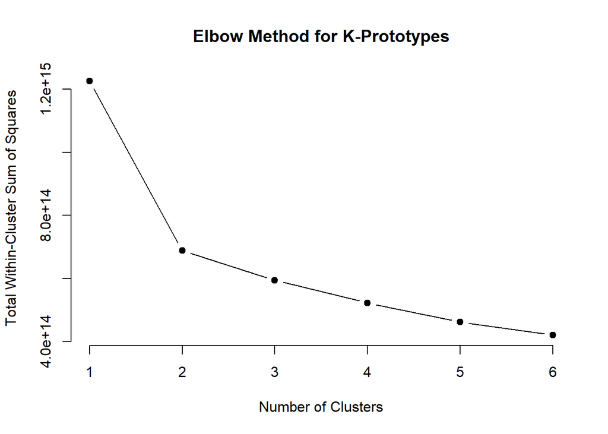

```r
load("kproto_wss.RData")

# Plot the elbow method
plot(1:6, kproto_wss, type = "b", pch = 19, frame = FALSE,
     xlab = "Number of Clusters", ylab = "Total Within-Cluster Sum of Squares",
     main = "Elbow Method for K-Prototypes")
```

```r
# Perform k-prototype clustering

types_vector <- c(rep('n', 12), rep('c', 4))


kproto_result <- kproto(cluster_df_clean, k = 2, types = types_vector)

cluster_df_clean_region$cluster_kproto <- as.factor(kproto_result$cluster)
```

### K Means cannot deal with categorical variables, so they are removed.

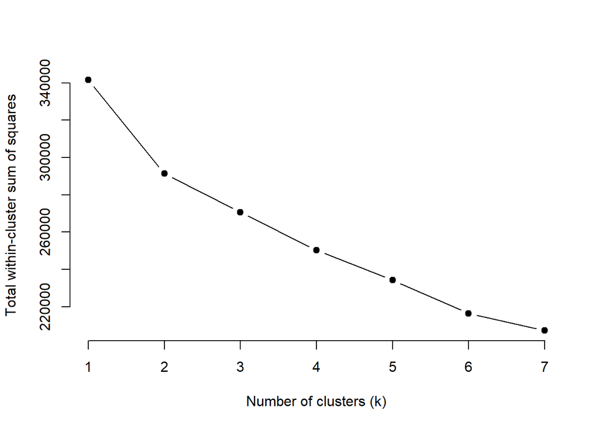

```r
cluster_df_clean_cov <- cluster_df_clean %>%
  select(-spotify_id, -is_explicit, -key, -time_signature)


# Standardize numeric variables (if needed)
cluster_df_clean_scaled <- cluster_df_clean_cov %>%
  mutate(across(where(is.numeric), scale))

set.seed(123)  # For reproducibility

sampled_data <- cluster_df_clean_scaled[sample(nrow(cluster_df_clean_scaled), size = 0.1 * nrow(cluster_df_clean_scaled)), ]



wss <- function(k) {
  kmeans(sampled_data, centers = k, nstart = 10, iter.max = 100)$tot.withinss
}

# Apply WSS for a range of cluster numbers
k_values <- 1:7

wss_values <- sapply(k_values, wss)

# Plot the Elbow Method
plot(k_values, wss_values, type = "b", pch = 19, frame = FALSE,
     xlab = "Number of clusters (k)", ylab = "Total within-cluster sum of squares")
```

### There are small elbows at 2, 4, 6; we will look into these three options.

```r
cluster_df_clean_cov <- cluster_df_clean %>%
  select(-spotify_id, -is_explicit, -key, -time_signature)


# Standardize numeric variables (if needed)
cluster_df_clean_scaled <- cluster_df_clean_cov %>%
  mutate(across(where(is.numeric), scale))

sampled_data <- cluster_df_clean_scaled[sample(nrow(cluster_df_clean_scaled), size = 0.1 * nrow(cluster_df_clean_scaled)), ]
```

```r
k <- 2  # Replace with the chosen number of clusters
kmeans_result <- kmeans(cluster_df_clean_scaled, centers = k, nstart = 25)

# Add cluster assignments to the dataframe
cluster_df_clean_region$cluster_kmeans2 <- as.factor(kmeans_result$cluster)
```

```r
k <- 4  # Replace with the chosen number of clusters
kmeans_result <- kmeans(cluster_df_clean_scaled, centers = k, nstart = 25)

# Add cluster assignments to the dataframe
cluster_df_clean$cluster_kmeans4 <- as.factor(kmeans_result$cluster)
```

```r
# Perform K-means clustering
k <- 6  # Replace with the chosen number of clusters
kmeans_result <- kmeans(cluster_df_clean_scaled, centers = k, nstart = 25)

# Add cluster assignments to the dataframe
cluster_df_clean$cluster_kmeans6 <- as.factor(kmeans_result$cluster)
```

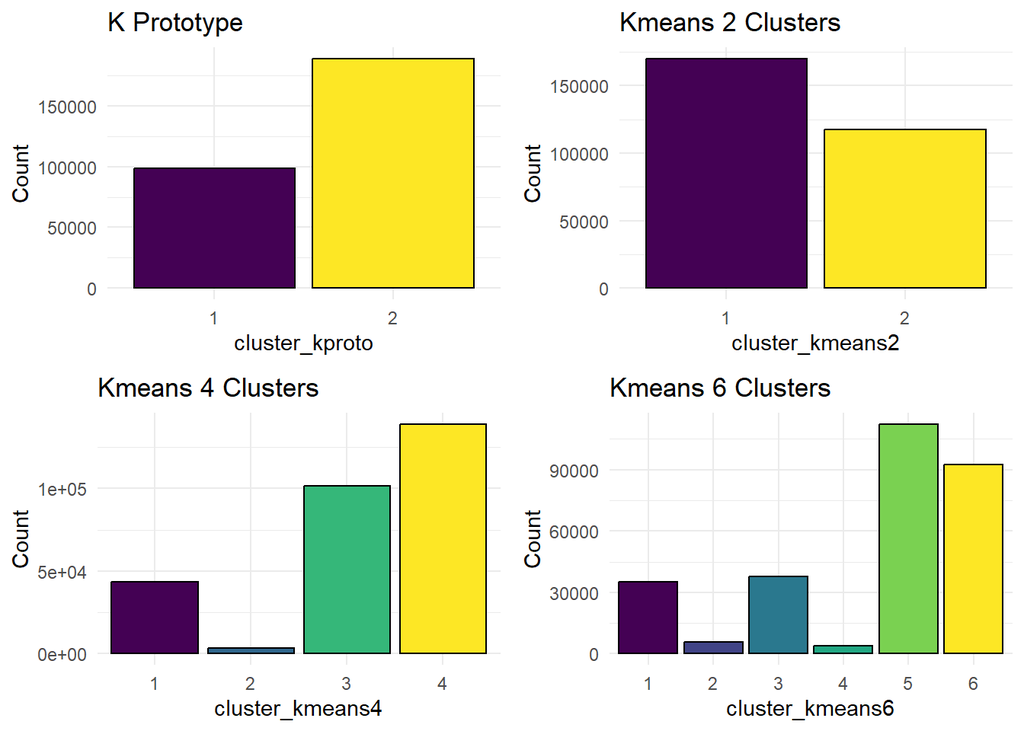

```r
p1 <- ggplot(cluster_df_clean_region, aes(x = cluster_kproto, fill = cluster_kproto)) +
  geom_bar( color = "black", show.legend = FALSE) +
  scale_fill_viridis_d() +
  labs(title = "K Prototype", x = "cluster_kproto", y = "Count") +
  theme_minimal()

p2 <- ggplot(cluster_df_clean_region, aes(x = cluster_kmeans2, fill = cluster_kmeans2)) +
  geom_bar( color = "black", show.legend = FALSE) +
  scale_fill_viridis_d() +
  labs(title = "Kmeans 2 Clusters", x = "cluster_kmeans2", y = "Count") +
  theme_minimal()

p3 <- ggplot(cluster_df_clean_region, aes(x = cluster_kmeans4, fill = cluster_kmeans4)) +
  geom_bar( color = "black", show.legend = FALSE) +
  scale_fill_viridis_d() +
  labs(title = "Kmeans 4 Clusters", x = "cluster_kmeans4", y = "Count") +
  theme_minimal()

p4 <- ggplot(cluster_df_clean_region, aes(x = cluster_kmeans6, fill = cluster_kmeans6)) +
  geom_bar( color = "black", show.legend = FALSE) +
  scale_fill_viridis_d() +
  labs(title = "Kmeans 6 Clusters", x = "cluster_kmeans6", y = "Count") +
  theme_minimal()

# Arrange the plots in a 2x2 grid

grid.arrange(p1, p2, p3, p4, ncol = 2)
```

```r
knitr::include_app("https://elizabethelsen80.shinyapps.io/Final_Cluster_Eval/", height = "800px")
```

[interactive chart not shown]

## Cluster Analysis

### K Prototype:

#### 1) long duration songs

#### 2) short songs

### K Means 2 Clusters :

#### 1) Younger, Short, loud, speechy happy songs that are generally better to dance to.

#### 2) Older, longer, less speechy, more somber songs

### K Means 4 Clusters:

#### 1) high speechiness probably rap, meme songs, musical music, or TikTok trends

#### 2) High Instrumental probably study songs

#### 3) longer duration, acoustic, lower energy, lower happiness, subdued songs

#### 4) Happy dance songs (high valence, high energy, high danceability

### K Means 6 Clusters:

#### 1) Live Recordings

#### 2) Older songs

#### 3) High Speechiness, so probably rap, meme songs, musical music, or TikTok trends

#### 4) Insturmental Music

#### 5) More general happy loud dance songs

#### 6) Sad acoustic songs

```r
cluster_df_clean_region_test <- cluster_df_clean_region[sample(nrow
                                                                          (cluster_df_clean_region)
                                                                          , size = 1000),]


contingency_table <- table(cluster_df_clean_region_test$cluster_kproto, cluster_df_clean_region_test$region)
chi2_result <- chisq.test(contingency_table)
print(chi2_result)
```

```
##
##  Pearson's Chi-squared test
##
## data:  contingency_table
## X-squared = 64.833, df = 11, p-value = 1.158e-09
```

```r
cramerV <- cramerV(contingency_table, bias.correct = TRUE)
print(cramerV)
```

```
## Cramer V
##   0.2321
```

```r
contingency_table <- table(cluster_df_clean_region_test$cluster_kmeans2, cluster_df_clean_region_test$region)
chi2_result <- chisq.test(contingency_table)
print(chi2_result)
```

```
##
##  Pearson's Chi-squared test
##
## data:  contingency_table
## X-squared = 69.598, df = 11, p-value = 1.456e-10
```

```r
cramerV <- cramerV(contingency_table, bias.correct = TRUE)
print(cramerV)
```

```
## Cramer V
##   0.2422
```

```r
contingency_table <- table(cluster_df_clean_region_test$cluster_kmeans4, cluster_df_clean_region_test$region)
chi2_result <- chisq.test(contingency_table)
print(chi2_result)
```

```
##
##  Pearson's Chi-squared test
##
## data:  contingency_table
## X-squared = 126.66, df = 33, p-value = 6.687e-13
```

```r
cramerV <- cramerV(contingency_table, bias.correct = TRUE)
print(cramerV)
```

```
## Cramer V
##   0.1769
```

```r
contingency_table <- table(cluster_df_clean_region_test$cluster_kmeans6, cluster_df_clean_region_test$region)
chi2_result <- chisq.test(contingency_table)
print(chi2_result)
```

```
##
##  Pearson's Chi-squared test
##
## data:  contingency_table
## X-squared = 191.37, df = 55, p-value < 2.2e-16
```

```r
cramerV <- cramerV(contingency_table, bias.correct = TRUE)
print(cramerV)
```

```
## Cramer V
##   0.1655
```

##### Low P values indicate a relationship between the region and the proportion of each cluster within it.

##### Cramer V says that the sample size has a low to moderately low effect on the Chi-Squared test.

###### ~~~~~~~~~~~~~~~~~~~~~~~~~~~~~~~~~~~~~~~~~~~~~~~~~~~~~~~~~~~~~~~~~~~~~~~~~~~

#### K Prototype:

##### In Most Regions songs under 4 minutes dominate the charts.

##### Anglo-Western, East Asian, Middle Eastern, and South-Central Asian countries have charts nearly even short and long songs. Southeast Asian countries Have more long songs on the charts than short songs

#### K Means 2 Clusters:

##### Short, loud, happy songs are more popular in most countries.

##### The two clusters are about even in Aftican, Anglo-Western, East Asian, Middle Eastern, and South-Central Asian countries.

#### Somber songs are more popular in Southeast Asian countries.

#### K Means 4 Clusters:

##### In Latin American countries there are many more happy dance songs than other songs on the charts.

##### In African countries’ charts there are about equal proportions of trendy, somber, and dance songs.

##### Anglo-Western and East Asian countries have very similar demographics.

##### In Southeast Asian countries’ charts there are more somber songs on the charts than dance songs. There are very few trend songs and insturmental songs in their charts.

#### K Means 6 Clusters:

##### Older songs make up the highest proportion of the charts in Anglo-Western countries.

##### Live Recordings were most popular on the Portuguese-speaking countries’ charts.

##### Songs with high proportions of spoken words are most popular on African and Portuguese-speaking countries’ charts.

##### Instrumental songs are rare on all of the charts.

##### Dance songs are most popular in Latin American countries’ charts, and least popular in South Central Asian and African countries’ Charts.

##### Once again Somber Acoustic songs are most popular on Southeast Asian countries’ charts and least popular in Latin American and Portuguese countries’ charts.